# Concepts and Basics of the SciencesPo Package

# 7 Political Behavior Measures

There is a specific vignette for [Indices](https://cran.r-project.org/web/packages/SciencesPo/vignettes/Indices.html), covering in great detail many of the political behaviour indices.

## 7.1 Measures of Political Diversity

Let’s consider the 1980’s US presidential election (vote share) to compute the effective number of electoral parties (ENEP).

```
 Democratic  Republican Independent Libertarian    Citizens      Others
      0.410       0.507       0.066       0.011       0.003       0.003
```

```r
PoliticalDiversity(US1980, index = "laakso/taagepera");
```

```
[1] 2.328
```

```r
PoliticalDiversity(US1980, index = "golosov");
```

```
[1] 2.597
```

Considers the following `data.frame` with electoral results for the 1999 election in Helsinki, the seats were allocated using both Saint-Laguë and D’Hondt methods:

```
   votes seats.SL seats.dH
1  68885        5        5
2  18343        1        1
3  86448        6        7
4  21982        1        1
5  51587        4        4
6  27227        2        2
7   8482        1        0
8   7250        0        0
9    365        0        0
10  2734        0        0
11  1925        0        0
12   475        0        0
13  1693        0        0
14   693        0        0
15   308        0        0
16   980        0        0
17   560        0        0
18   590        0        0
19   185        0        0
```

```r
# ENEP defaults (laakso/taagepera) method

with(Helsinki, PoliticalDiversity(votes)); #ENEP Votes
```

```
[1] 5.453
```

```r
with(Helsinki, PoliticalDiversity(seats.SL)); #ENP for Saint-Lague
```

```
[1] 4.762
```

```r
with(Helsinki, PoliticalDiversity(seats.dH)); #ENP for D'Hondt
```

```
[1] 4.167
```

## 7.2 Proportionality Measures

Let’s use the 2012 Quebec provincial election:

```
   party   votes pvotes seats pseats
1     PQ 1393703  31.95    54   43.2
2    Lib 1360968  31.20    50   40.0
3    CAQ 1180235  27.05    19   15.2
4     QS  263111   6.03     2    1.6
5 Option   82539   1.89     0    0.0
6  Green   43394   0.99     0    0.0
7 Others   38738   0.89     0    0.0
```

### 7.2.1 Rae’s proportionality index

```r
with(Quebec, Proportionality(pvotes, pseats,
                     index = "Rae") )
```

```
Rae's Index :  0.057
```

### 7.2.2 Loosemore-Hanby’s Proportionality Index

```r
with(Quebec, Proportionality(pvotes, pseats,
                     index = "Loosemore-Hanby") )
```

```
Loosemore-Hanby's Index :  0.201
```

### 7.2.3 Gallagher’s proportionality index

```r
with(Quebec, Proportionality(pvotes, pseats,
                     index = "Gallagher") )
```

```
Gallagher's Index :  0.136
```

## 7.3 Highest Averages Methods of Allocating Seats Proportionally

```
  PCdoB     PDT     PEN    PMDB     PRB     PSB     PSC    PSTU   PTdoB
 187906  326841  132531  981096 2043217   15061  103679  109830  213988
    PTC     PTN
  67145  278267
```

The basic imputs for this class of functions are: 1) a list of parties, 2) a list of positive votes, and 3) a constant value for the number of seats to be returned. A numeric value (0~1) for the threshold is optional.

### 7.3.1 d’Hondt

```r
HighestAverages(parties=names(Ceara), votes=Ceara,
                seats = 42, method = "dh")
```

```
Method: d'Hondt
Divisors: 1 2 3 4 ...
ENP: 3.65 (After): 3.14
Gallagher Index:  47.01
```

```
-------------------------
 Party   Seats   % Seats
------- ------- ---------
  PRB     21       50

 PMDB     10      23.8

  PDT      3       7.1

  PTN      2       4.8

 PTdoB     2       4.8

 PCdoB     1       2.4

  PEN      1       2.4

  PSC      1       2.4

 PSTU      1       2.4

  PSB      0        0

  PTC      0        0
-------------------------
```

The d’Hondt method is only one way of allocating seats in party list systems. Other methods include the Saint-Lague, the modified Saint-Lague, the Danish version, Imperiali (do not to confuse with the Imperiali quota which is a Largest remainder method), and Hungtinton-Hill.

### 7.3.2 Saint-Lague

```r
HighestAverages(parties=names(Ceara), votes=Ceara,
                seats = 42, method = "sl")
```

```
Method: Sainte-Laguë
Divisors: 1 3 5 7 ...
ENP: 3.65 (After): 3.74
Gallagher Index:  43.99
```

```
-------------------------
 Party   Seats   % Seats
------- ------- ---------
  PRB     19      45.2

 PMDB      9      21.4

  PDT      3       7.1

  PTN      3       7.1

 PCdoB     2       4.8

 PTdoB     2       4.8

  PEN      1       2.4

  PSC      1       2.4

 PSTU      1       2.4

  PTC      1       2.4

  PSB      0        0
-------------------------
```

### 7.3.3 Using thresholds

```r
HighestAverages(parties=names(Ceara), votes=Ceara,
               seats = 42, method = "dh", threshold = 5/100)
```

```
Method: d'Hondt
Divisors: 1 2 3 4 ...
ENP: 3.65 (After): 2.39
Gallagher Index:  53.23
```

```
-------------------------
 Party   Seats   % Seats
------- ------- ---------
  PRB     24      57.1

 PMDB     12      28.6

  PDT      3       7.1

  PTN      3       7.1

 PCdoB     0        0

  PEN      0        0

  PSB      0        0

  PSC      0        0

 PSTU      0        0

  PTC      0        0

 PTdoB     0        0
-------------------------
```

Other methods divide the votes by a mathematically derived quota, such as the Droop quota, the Hare quota (or Hamilton/Vinton), or the Imperiali quota, see next.

## 7.4 Largest Remainder Methods of Allocating Seats Proportionally

### 7.4.1 Hare quota

```r
LargestRemainders(parties=names(Ceara), votes=Ceara,
                seats = 42, method = "hare")
```

[output not shown]

### 7.4.2 Droop quota

```r
LargestRemainders(parties=names(Ceara), votes=Ceara,
                seats = 42, method = "droop")
```

[output not shown]

## 7.5 Suitable output for recycling in rmarkdown documents

The output produced by the `highestAveragesof()` and `largestRemainders()` functions is always a `data.frame`; therefore, it’s very straightforward to use with other aplications. For instance, I like the idea of using the output with **knitr** (2016) and **ggplot2** (2009) packages to produce publishable-quality tables and graphs.

```r
mytable = HighestAverages(parties=names(Ceara), votes=Ceara,
                seats = 42, method = "dh")
```

```
Method: d'Hondt
Divisors: 1 2 3 4 ...
ENP: 3.65 (After): 3.14
Gallagher Index:  47.01
```

```r
library(knitr)

kable(mytable, align=c("l","c","c"))
```

| Party | Seats | % Seats |
| --- | --- | --- |
| PRB | 21 | 50.0 |
| PMDB | 10 | 23.8 |
| PDT | 3 | 7.1 |
| PTN | 2 | 4.8 |
| PTdoB | 2 | 4.8 |
| PCdoB | 1 | 2.4 |
| PEN | 1 | 2.4 |
| PSC | 1 | 2.4 |
| PSTU | 1 | 2.4 |
| PSB | 0 | 0.0 |
| PTC | 0 | 0.0 |

```r
mytable = HighestAverages(parties=names(Ceara), votes=Ceara,
                seats = 42, method = "dh")
```

```
Method: d'Hondt
Divisors: 1 2 3 4 ...
ENP: 3.65 (After): 3.14
Gallagher Index:  47.01
```

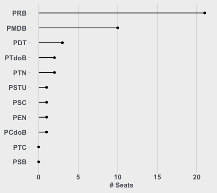

2014 Legislative Election in Ceara (M=42)

```r
p <- ggplot(mytable, aes(x=reorder(Party, Seats), y=Seats)) +
  geom_lollipop() + coord_flip() + labs(x=NULL, y="# Seats")
p + theme_538() + theme(panel.grid.major.y = element_blank())
```

## 7.6 Measures of inequality and concentration

### 7.6.1 Lorenz curve

```
$p
 [1] 0.0000000 0.2264877 0.2303473 0.3608878 0.4116205 0.6213280 0.7130032
 [8] 0.7581524 0.8769094 1.0000000

$L
 [1] 0.0000000 0.1955209 0.1990112 0.3231465 0.3731350 0.5883759 0.6829786
 [8] 0.7313230 0.8617789 1.0000000

$L.general
 [1]   0.0000 176.2074 179.3530 291.2262 336.2768 530.2563 615.5142
 [8] 659.0832 776.6527 901.2203

attr(,"class")
[1] "lorenz"
```

### 7.6.2 Gini Index

```r
x <- c(778, 815, 857, 888, 925, 930, 965, 990, 1012)

wgt <- runif(n=length(x))

Gini(x, wgt)
```

```
[1] 0.03611
```

### 7.6.3 Atkinson’s Index

```r
x <- c(778, 815, 857, 888, 925, 930, 965, 990, 1012)

Atkinson(x, epsilon = 0.5)
```

```
[1] 0.001719
```

# 8 Plot Themes & Colors

The **SciencesPo** brings in few themes and color palettes to enhance ggplot2 graphs, but there are specialized packages like ggthemes, ggthemr, cowplot, ggalt, GGally, and sjPlot that can make graph decoration a lot easier. There’s also an interesting discussion on plot design in the outstanding reference [Cookbook for R](http://www.cookbook-r.com/Graphs/Legends_%28ggplot2%29/) that might be of your interest.

With **SciencesPo**, one can “preview” ggplot themes by simply invoking the `Previewplot()` function. This will draw a predefined plot that we can combine with themes, for instance.

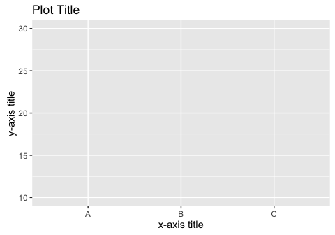

```r
Previewplot() + theme_grey()
```

## 8.1 Themes

In my point of view, the default **ggplot2** design has its charm, but, very often I don’t like the gray background grid. I feel it distracts from the data. For example, see the following **ggplot2** graph with default settings on.

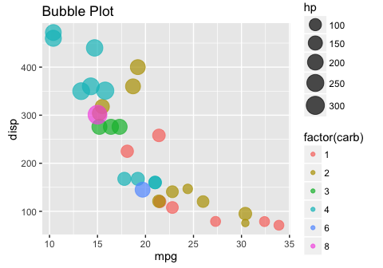

```r
# detach("package:SciencesPo", unload = TRUE)

gg <- ggplot(mtcars, aes(mpg, disp,color=factor(carb),size=hp))
gg <- gg + geom_point(alpha=0.7) + labs(title="Bubble Plot")
gg <- gg +scale_size_continuous(range = c(3,8))
gg
```

- `theme_blank()` Produces a consistent theme for ggplot2 graphs with no background, axis texts, or grid lines.

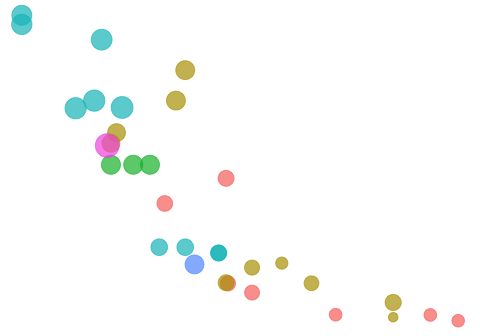

```r
library(SciencesPo)

gg <- ggplot(mtcars, aes(mpg, disp,color=factor(carb),size=hp))
gg <- gg + geom_point(alpha=0.7) + labs(title="Bubble Plot")
gg <- gg +scale_size_continuous(range = c(3,8))
gg <- gg + theme_blank()
gg
```

- `theme_pub()` Produces a consistent theme for ggplot2 graphs with a white background and fewer grid lines.

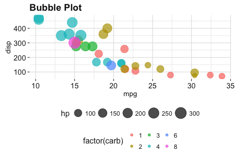

```r
library(SciencesPo)

gg <- ggplot(mtcars, aes(mpg, disp,color=factor(carb),size=hp))
gg <- gg + geom_point(alpha=0.7) + labs(title="Bubble Plot")
gg <- gg +scale_size_continuous(range = c(3,8))
gg <- gg + theme_pub()
gg
```

- `theme_fte()` Produces a consistent theme for ggplot2 graphs, similar to the plots used in the http://fivethirtyeight.com/.

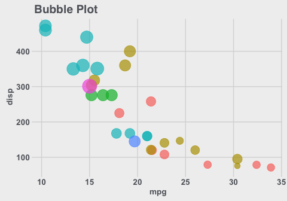

[figure not shown]

```r
library(SciencesPo)

gg <- ggplot(mtcars, aes(mpg, disp,color=factor(carb),size=hp))
gg <- gg + geom_point(alpha=0.7) + labs(title="Bubble Plot")
gg <- gg +scale_size_continuous(range = c(3,8))
gg <- gg + theme_538()
gg
```

- `theme_darkside()` Produces a consistent theme for ggplot2 graphs with a dark background and fewer grid lines.

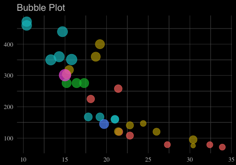

```r
library(SciencesPo)

gg <- ggplot(mtcars, aes(mpg, disp,color=factor(carb),size=hp))
gg <- gg + geom_point(alpha=0.7) + labs(title="Bubble Plot")
gg <- gg +scale_size_continuous(range = c(3,8))
gg <- gg + theme_darkside()
gg
```

## 8.2 Changing defaults

If you want to change the theme for an entire session you can use `theme_set()` as in `theme_set(theme_gray())` to switch to default **ggplot2** theme for all subsequent plots. Otherwise, you may also apply themes without changing the defaults as of `plot + theme_pub()`.

To modify general aspects of the `theme_pub()` as fontsize, font family, color etc:

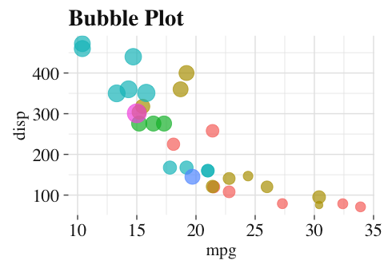

```r
require(SciencesPo)

# "Verdana", "Tahoma", "Gill Sans" "serif" and "sans" are also high-readability fonts
theme_set(theme_pub(base_size=18, base_family = "serif"))
```

Modify it with `theme()`. You might modify text sizes, colors etc; then add to the plot.

```r
prefs <- theme(axis.text = element_text(size=18,
                                        family = "Gill Sans",
                                        colour="red"))
```

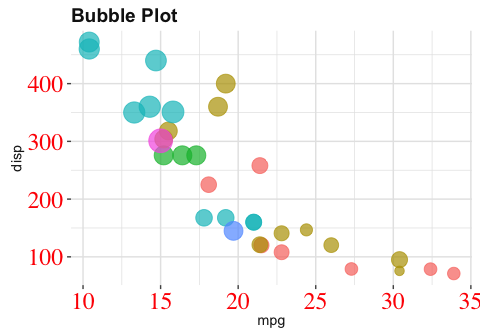

### 8.2.1 Quick plot customization

Alternatively, we can use a set of built in function to quick plot customization:

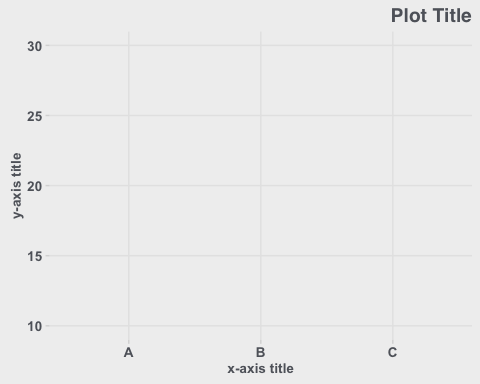

```r
Previewplot() +
  theme_538() +
  align_title_right()
```

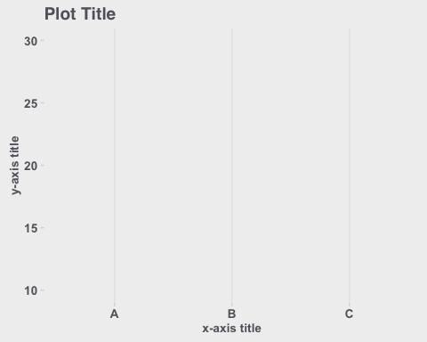

```r
Previewplot() +
  theme_538() +
  no_y_gridlines()
```

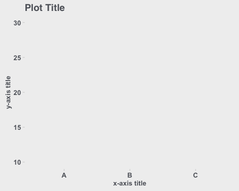

```r
Previewplot() +
  theme_538() +
  no_y_gridlines() +
  no_x_gridlines()
```

## 8.3 Generic plot annotations

The function `Footnote()` can be handy for adding extra text information, such as data source, equation, or credits as footnotes to a *ggplot2* or gtable objects. The next chunck demonstrates its usage:

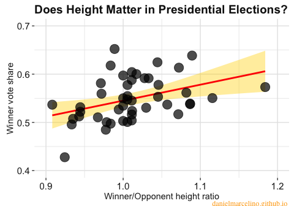

```r
gg <- ggplot(Presidents, aes(x=height_ratio, y=vote_support))
gg <- gg + geom_smooth(method=lm, colour="red", fill="gold")
gg <- gg + geom_point(size = 5, alpha = .7)
gg <- gg +  xlim(0.9,1.2) + ylim(.40, .70)
gg <- gg + labs(x="Winner/Opponent height ratio", y="Winner vote share", title="Does Height Matter in Presidential Elections?")
gg <- gg + theme_pub()

# Commence adding layers here
Render(gg) + Footnote(note="danielmarcelino.github.io", color="orange")
```

## 8.4 Generic plots (Data Visualization 101)

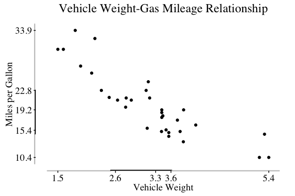

```r
with(mtcars, Scatterplot(x = wt, y = mpg,
main = "Vehicle Weight-Gas Mileage Relationship",
xlab = "Vehicle Weight",
ylab = "Miles per Gallon",
font.family = "serif") )
```

## 8.5 Enhanced geoms

## 8.6 Color palettes

The following scales help passing manual values to scale colors for ggplot2 objects. In many ways, I think these scales are consistent with the themes whitin the **SciencesPo** package described earlier.

- `scale_color_pub()`
- `scale_fill_pub()`
- `scale_shape_pub()`
- `scale_color_party()`
- `scale_fill_party()`

## 8.7 Discrete palletes

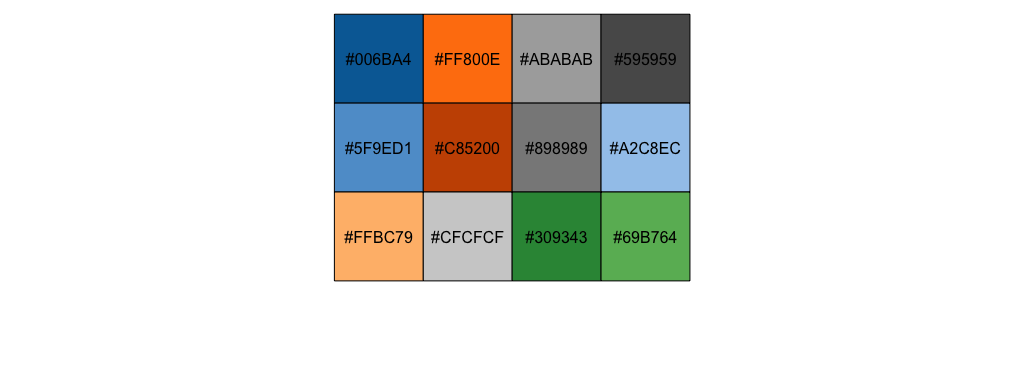

```r
library("scales", quietly = TRUE)

show_col(pub_pal("pub12")(12))
```

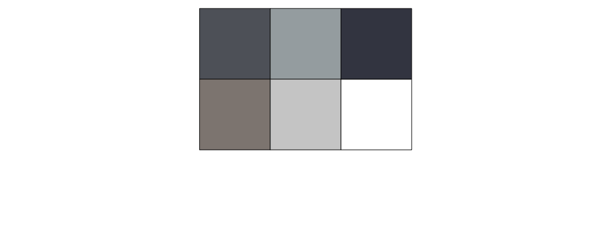

```r
show_col(pub_pal("gray5")(6), labels = FALSE)
```

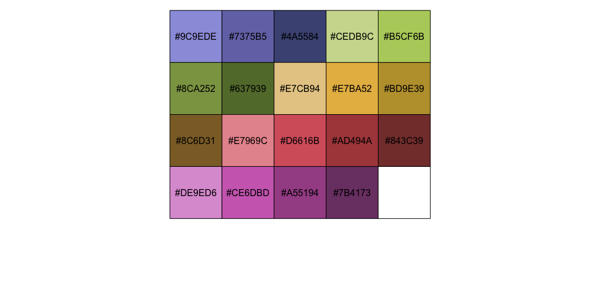

```r
show_col(pub_pal("manyeyes")(20))
```

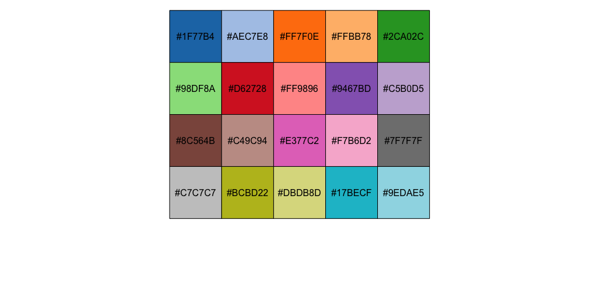

```r
show_col(pub_pal("tableau20")(20))
```

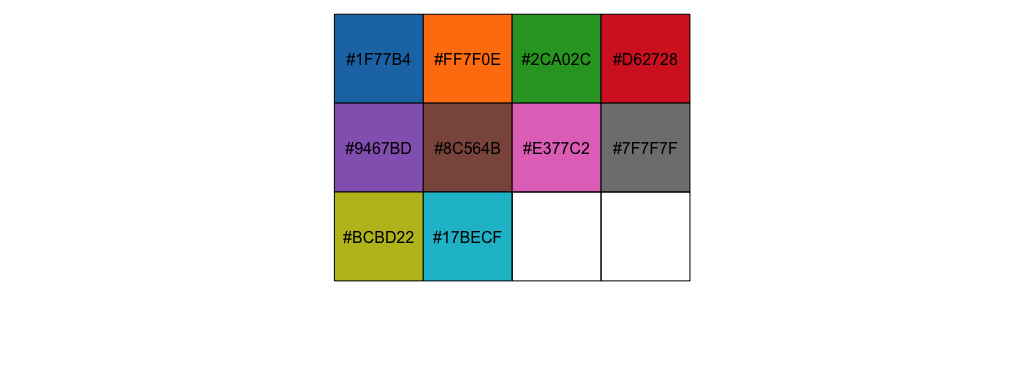

```r
show_col(pub_pal("tableau10")(10))
```

```r
 show_col(pub_pal("tableau10light")(10))
```

[figure not shown]

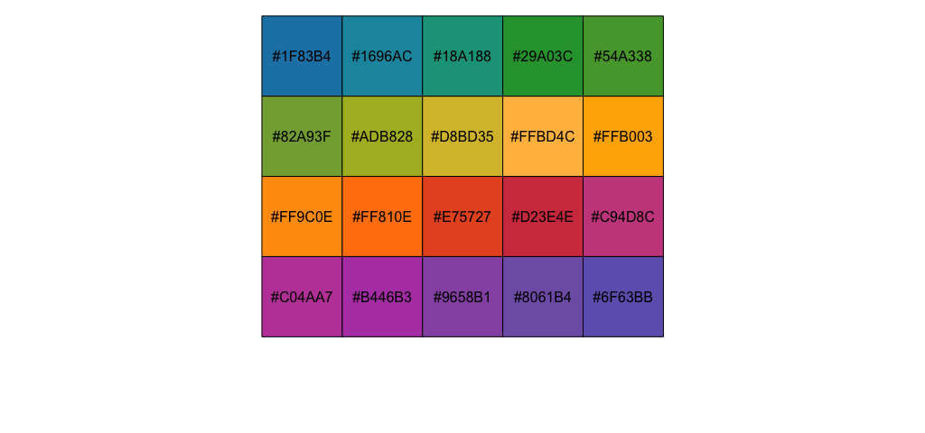

```r
show_col(pub_pal("cyclic")(20))
```

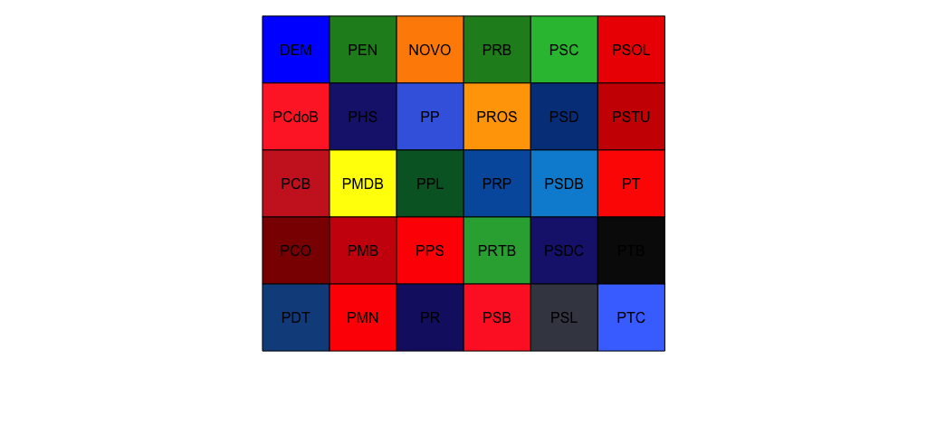

```r
party_pal("BRA", plot=TRUE)
```

## 8.8 Continuous palletes

### 8.8.1 Bivariate scales

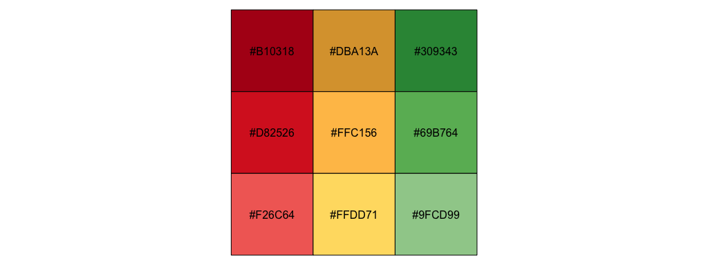

```r
show_col(pub_pal("trafficlight")(9))
```

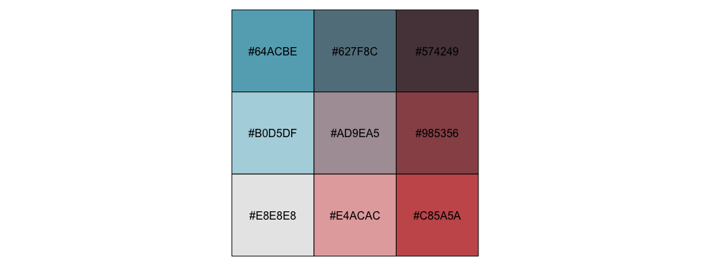

```r
show_col(pub_pal("bivariate1")(9))
```

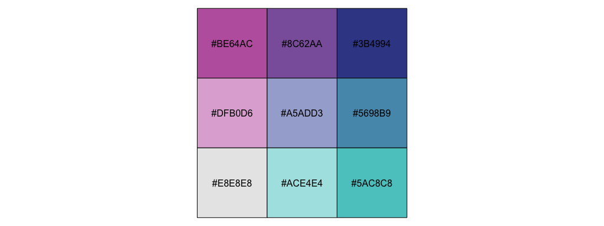

```r
show_col(pub_pal("bivariate2")(9))
```

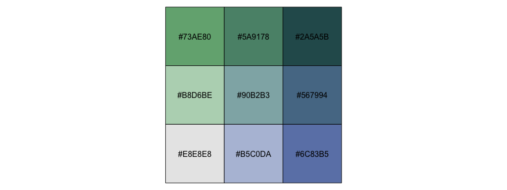

```r
show_col(pub_pal("bivariate3")(9))
```

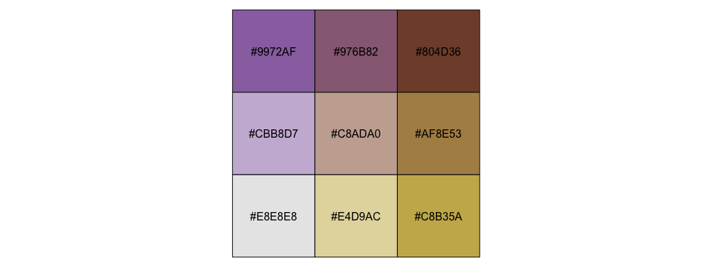

```r
show_col(pub_pal("bivariate4")(9))
```

# 9 R Session Details

```
 setting  value
 version  R version 3.3.0 (2016-05-03)
 system   x86_64, darwin14.5.0
 ui       X11
 language (EN)
 collate  C
 tz       America/Sao_Paulo
 date     2016-08-04

 package    * version    date       source
 R6           2.1.2      2016-01-26 CRAN (R 3.3.0)
 Rcpp         0.12.6     2016-07-19 CRAN (R 3.3.0)
 SciencesPo * 1.4.1      2013-08-27 CRAN
 assertthat   0.1        2013-12-06 cran (@0.1)
 chron        2.3-47     2015-06-24 cran (@2.3-47)
 codetools    0.2-14     2015-07-15 CRAN (R 3.3.0)
 colorspace   1.2-6      2015-03-11 cran (@1.2-6)
 crayon       1.3.2      2016-06-28 CRAN (R 3.3.0)
 data.table   1.9.6      2015-09-19 cran (@1.9.6)
 devtools   * 1.12.0     2016-06-24 CRAN (R 3.3.0)
 digest       0.6.9      2016-01-08 CRAN (R 3.3.0)
 evaluate     0.9        2016-04-29 CRAN (R 3.3.0)
 formatR      1.4        2016-05-09 CRAN (R 3.3.0)
 ggplot2    * 2.1.0.9000 2016-08-04 Github (hadley/ggplot2@91859da)
 gtable       0.2.0      2016-02-26 cran (@0.2.0)
 htmltools    0.3.5      2016-03-21 CRAN (R 3.3.0)
 httpuv       1.3.3      2015-08-04 CRAN (R 3.3.0)
 knitr      * 1.13       2016-05-09 CRAN (R 3.3.0)
 lubridate    1.5.6      2016-04-06 cran (@1.5.6)
 magrittr     1.5        2014-11-22 CRAN (R 3.3.0)
 memoise      1.0.0      2016-01-29 CRAN (R 3.3.0)
 mime         0.5        2016-07-07 CRAN (R 3.3.0)
 munsell      0.4.3      2016-02-13 cran (@0.4.3)
 pander       0.6.0      2015-11-23 cran (@0.6.0)
 plyr         1.8.4.9000 2016-07-27 Github (hadley/plyr@fe19241)
 rmarkdown    0.9.6.14   2016-07-27 Github (rstudio/rmarkdown@cb74ee5)
 roxygen2     5.0.1      2015-11-11 CRAN (R 3.3.0)
 rstudioapi   0.6        2016-06-27 CRAN (R 3.3.0)
 scales     * 0.4.0      2016-02-26 cran (@0.4.0)
 shiny        0.13.2     2016-03-28 CRAN (R 3.3.0)
 stringi      1.1.1      2016-05-27 CRAN (R 3.3.0)
 stringr      1.0.0      2015-04-30 CRAN (R 3.3.0)
 testthat     1.0.2      2016-04-23 CRAN (R 3.3.0)
 tibble       1.1        2016-07-04 cran (@1.1)
 withr        1.0.2      2016-06-20 CRAN (R 3.3.0)
 xtable       1.8-2      2016-02-05 CRAN (R 3.3.0)
 yaml         2.1.13     2014-06-12 CRAN (R 3.3.0)
```

# References

Arnold, Jeffrey B. 2016. *Ggthemes: Extra Themes, Scales and Geoms for ’Ggplot2’*. https://CRAN.R-project.org/package=ggthemes.

Lüdecke, Daniel. 2016. *SjPlot: Data Visualization for Statistics in Social Science*. http://CRAN.R-project.org/package=sjPlot.

Meyer, David, Evgenia Dimitriadou, Kurt Hornik, Andreas Weingessel, and Friedrich Leisch. 2015. *E1071: Misc Functions of the Department of Statistics, Probability Theory Group (Formerly: E1071), TU Wien*. https://CRAN.R-project.org/package=e1071.

R Core Team. 2016. *R: A Language and Environment for Statistical Computing*. Vienna, Austria: R Foundation for Statistical Computing. https://www.R-project.org/.

Rudis, Bob. 2016. *Ggalt: Extra Coordinate Systems, Geoms and Statistical Transformations for ’Ggplot2’*. https://CRAN.R-project.org/package=ggalt.

Schloerke, Barret, Jason Crowley, Di Cook, Francois Briatte, Moritz Marbach, Edwin Thoen, and Amos Elberg. 2016. *GGally: Extension to Ggplot2*. https://CRAN.R-project.org/package=GGally.

Wickham, Hadley. 2009. *Ggplot2: Elegant Graphics for Data Analysis*. Springer-Verlag New York. http://ggplot2.org.

Wilke, Claus O. 2016. *Cowplot: Streamlined Plot Theme and Plot Annotations for ’Ggplot2’*. https://CRAN.R-project.org/package=cowplot.

Xie, Yihui. 2016. *Knitr: A General-Purpose Package for Dynamic Report Generation in R.* https://CRAN.R-project.org/package=knitr.